# My YouTube Viewing Habits

Exploring my YouTube viewing habits using data collected using a Google Form every time I watch a YouTube video.

[figure not shown]

## Yes, you *May* know about my YouTube watch time

Starting from May 5th, I began logging data again on the YouTube videos I watched. Compared to the previous logs, this time I recorded how far I got into the video for a more accurate representation of my total watch time.

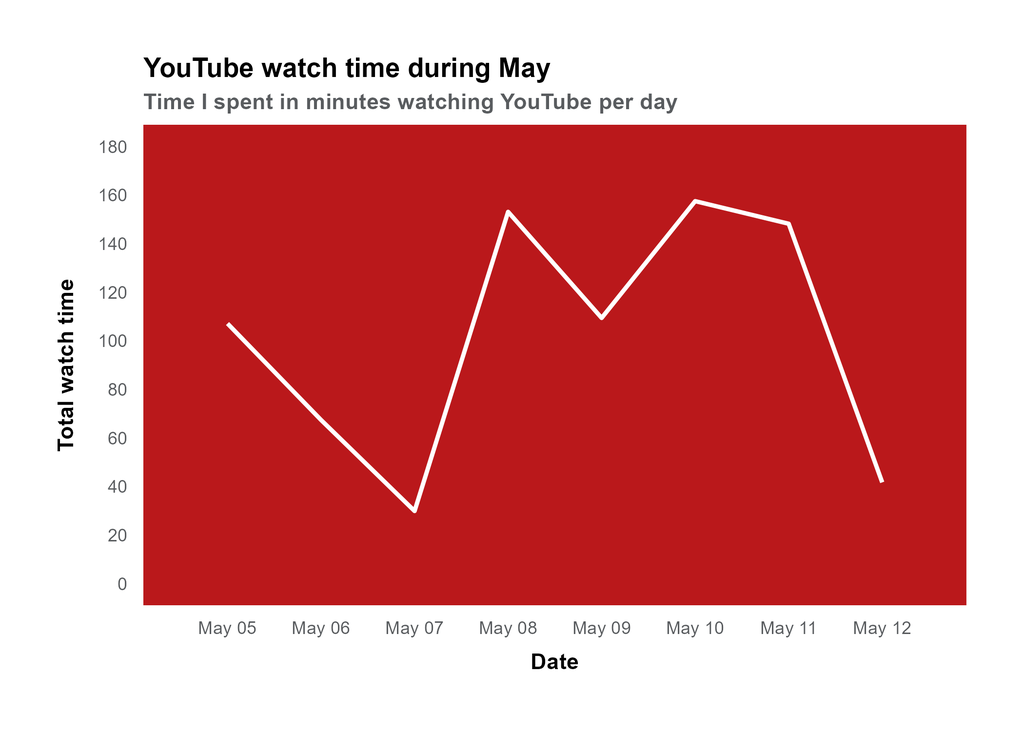

Line graph of watch time each day from May 5th to 12th

My total watch time was different each day. There were days where it dropped down to less than 40 minutes and days where it neared 160 minutes.

## YouTube Prime Time

I collected the times I started watching a YouTube video and then grouped them by time of the day from morning to night. Looking at the proportions, there seems to be certain times of day where I am more likely to be watching YouTube videos.

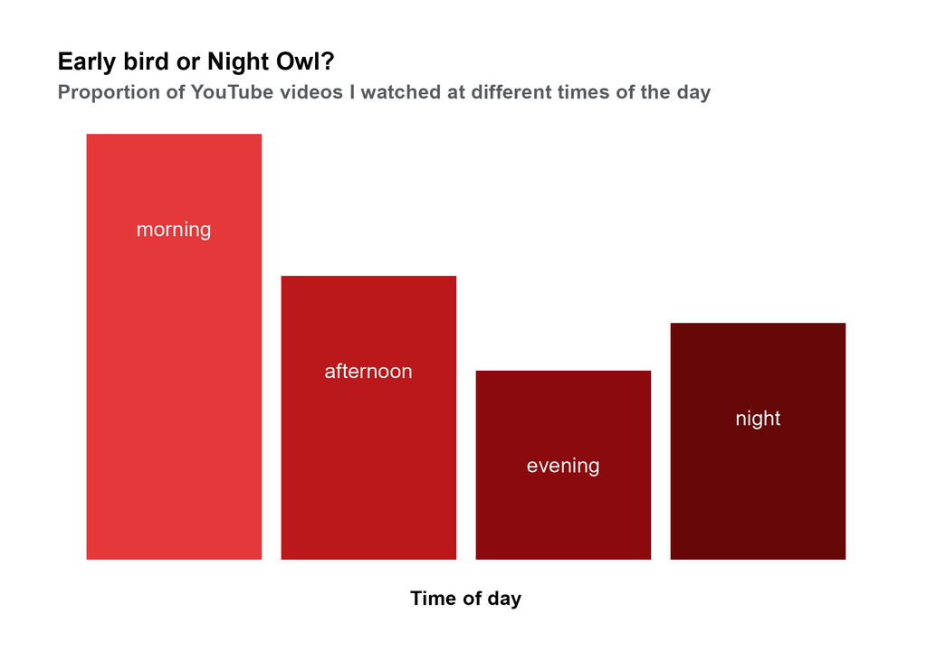

Proportion of YouTube videos watched from morning to night

A greater proportion of videos were watched in the morning. The number of videos decreases as the day progresses from morning to afternoon and afternoon to evening. Watching YouTube picks back up during night time.

## Everything everywhere all at once… except my attention

The videos I watch while I am multitasking are more varied, with engagement levels being spread across 1 to 5.

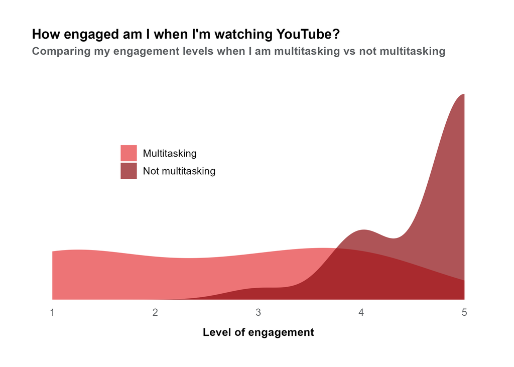